# Data Analysis: Switzerland's Demography and Geography

*Report by Adi Agimba*

```python
import pandas as pd
import numpy as np
import matplotlib.pyplot as plt
import seaborn as sns
import scipy.stats as stats

%matplotlib inline
```

## **A. An overview of the dataset**

**1) Import the data as a Pandas DataFrame and name it as df**

```python
df_raw = pd.read_csv("p1_communes.csv")
```

**2) Check the number of rows and columns**

```python
print(f"The dataframe has {df_raw.shape[0]} rows and {df_raw.shape[1]} columns")
```

```
The dataframe has 2202 rows and 17 columns
```

**3) Display the first few entries of the DataFrame**

```python
print(f"The first 20 entries of the dataset:\n ")
df_raw.head(20)
```

```
The first 20 entries of the dataset:
```

|  | Canton | Commune | Language | Residents | Population density per km² | 0-19 years | 20-64 years | 65 years or over | Private households | Surface area in km² | Settlement area | Agricultural area | Wooded area | Unproductive area | East coordinate | North coordinate | Elevation |
| --- | --- | --- | --- | --- | --- | --- | --- | --- | --- | --- | --- | --- | --- | --- | --- | --- | --- |
| 0 | ZH | Aeugst am Albis | de | 1982 | 250.568900 | 19.677094 | 62.764884 | 17.558022 | 835 | 7.91 | 12.658228 | 51.139241 | 30.886076 | 5.316456 | 2679300 | 1235700 | 673 |
| 1 | ZH | Affoltern am Albis | de | 12229 | 1154.768650 | 20.508627 | 61.329626 | 18.161747 | 5348 | 10.59 | 30.674264 | 40.170940 | 28.205128 | 0.949668 | 2676800 | 1236800 | 502 |
| 2 | ZH | Bonstetten | de | 5548 | 746.702557 | 23.666186 | 60.310022 | 16.023792 | 2325 | 7.43 | 15.456989 | 55.510753 | 28.629032 | 0.403226 | 2677800 | 1241000 | 583 |
| 3 | ZH | Hausen am Albis | de | 3701 | 272.132353 | 21.804918 | 60.686301 | 17.508781 | 1546 | 13.60 | 12.692590 | 55.906090 | 28.833456 | 2.567865 | 2682900 | 1233100 | 653 |
| 4 | ZH | Hedingen | de | 3734 | 571.822358 | 21.772898 | 61.756829 | 16.470273 | 1540 | 6.53 | 19.817073 | 46.341463 | 33.231707 | 0.609756 | 2676400 | 1239000 | 543 |
| 5 | ZH | Kappel am Albis | de | 1157 | 146.085859 | 25.237684 | 60.760588 | 14.001729 | 465 | 7.92 | 8.312020 | 69.948849 | 20.588235 | 1.150895 | 2682400 | 1231300 | 559 |
| 6 | ZH | Knonau | de | 2373 | 366.769706 | 23.893805 | 61.061947 | 15.044248 | 925 | 6.47 | 18.027735 | 62.249615 | 17.103236 | 2.619414 | 2677500 | 1230900 | 454 |
| 7 | ZH | Maschwanden | de | 656 | 139.872068 | 23.018293 | 59.756098 | 17.225610 | 272 | 4.69 | 8.974359 | 59.615385 | 23.717949 | 7.692308 | 2674800 | 1232000 | 410 |
| 8 | ZH | Mettmenstetten | de | 5094 | 390.943975 | 22.732627 | 59.776207 | 17.491166 | 2050 | 13.03 | 15.990819 | 64.269319 | 18.592196 | 1.147666 | 2677600 | 1233000 | 493 |
| 9 | ZH | Obfelden | de | 5599 | 742.572944 | 23.504197 | 59.778532 | 16.717271 | 2302 | 7.54 | 24.338624 | 49.074074 | 21.428571 | 5.158730 | 2675100 | 1235300 | 439 |
| 10 | ZH | Ottenbach | de | 2555 | 508.964143 | 19.882583 | 59.295499 | 20.821918 | 1106 | 5.02 | 20.758483 | 54.690619 | 20.359281 | 4.191617 | 2673000 | 1237200 | 435 |
| 11 | ZH | Rifferswil | de | 1123 | 172.503840 | 27.871772 | 56.544969 | 15.583259 | 442 | 6.51 | 10.334347 | 64.893617 | 22.644377 | 2.127660 | 2680100 | 1232800 | 591 |
| 12 | ZH | Stallikon | de | 3680 | 306.156406 | 20.679348 | 62.880435 | 16.440217 | 1525 | 12.02 | 11.064892 | 38.019967 | 49.833611 | 1.081531 | 2679500 | 1242100 | 641 |
| 13 | ZH | Wettswil am Albis | de | 5188 | 1376.127321 | 23.226677 | 56.823439 | 19.949884 | 2153 | 3.77 | 41.066667 | 34.133333 | 20.533333 | 4.266667 | 2678200 | 1243700 | 549 |
| 14 | ZH | Adlikon | de | 707 | 107.446809 | 20.933522 | 62.659123 | 16.407355 | 280 | 6.58 | 10.876133 | 63.897281 | 22.658610 | 2.567976 | 2694300 | 1271000 | 433 |
| 15 | ZH | Benken (ZH) | de | 855 | 151.060071 | 20.467836 | 64.327485 | 15.204678 | 361 | 5.66 | 8.112875 | 57.495591 | 34.038801 | 0.352734 | 2691300 | 1278800 | 440 |
| 16 | ZH | Berg am Irchel | de | 570 | 81.312411 | 14.385965 | 60.526316 | 25.087719 | 250 | 7.01 | 4.978663 | 48.079659 | 45.376956 | 1.564723 | 2687200 | 1269400 | 458 |
| 17 | ZH | Buch am Irchel | de | 977 | 95.690500 | 25.690890 | 60.081883 | 14.227226 | 371 | 10.21 | 6.889764 | 55.118110 | 37.992126 | 0.000000 | 2689100 | 1267000 | 552 |
| 18 | ZH | Dachsen | de | 1920 | 711.111111 | 21.510417 | 58.333333 | 20.156250 | 782 | 2.70 | 32.075472 | 48.301887 | 12.452830 | 7.169811 | 2688600 | 1280000 | 406 |
| 19 | ZH | Dorf | de | 658 | 118.345324 | 22.188450 | 61.246201 | 16.565350 | 257 | 5.56 | 12.454874 | 46.389892 | 40.974729 | 0.180505 | 2691000 | 1269800 | 472 |

**4) Obtain the index labels, and then show the column names as a list**

```python
print(f"A list of all the {df_raw.columns.nunique()} column labels:\n ")

print(list(df_raw.columns))
```

```
A list of all the 17 column labels:

['Canton', 'Commune', 'Language', 'Residents', 'Population density per km²', '0-19 years', '20-64 years', '65 years or over', 'Private households', 'Surface area in km²', 'Settlement area', 'Agricultural area', 'Wooded area', 'Unproductive area', 'East coordinate', 'North coordinate', 'Elevation']
```

**5) Check the data type for each column**

```python
print(f"The dataframe has {df_raw.dtypes.nunique()} unique data types:\n")

print(df_raw.dtypes)
```

```
The dataframe has 3 unique data types:

Canton                         object
Commune                        object
Language                       object
Residents                       int64
Population density per km²    float64
0-19 years                    float64
20-64 years                   float64
65 years or over              float64
Private households              int64
Surface area in km²           float64
Settlement area               float64
Agricultural area             float64
Wooded area                   float64
Unproductive area             float64
East coordinate                 int64
North coordinate                int64
Elevation                       int64
dtype: object
```

**6) Check if there are any missing values and show the rows that contain the missing values**

```python
print(f"Count of all the rows in each column with missing data values:\n")

df_raw.isnull().sum()
```

```
Count of all the rows in each column with missing data values:
```

```
Canton                         3
Commune                        0
Language                      11
Residents                      0
Population density per km²     0
0-19 years                     0
20-64 years                    0
65 years or over               0
Private households             0
Surface area in km²            0
Settlement area                0
Agricultural area              0
Wooded area                    0
Unproductive area              0
East coordinate                0
North coordinate               0
Elevation                      0
dtype: int64
```

```python
print(f"Of the two columns with NaN values, less than one percent of data\
 on Swiss cantons and spoken languages is missing:\n")

df_raw[["Canton", "Language"]].isnull().sum() / len(df_raw) * 100
```

```
Of the two columns with NaN values, less than one percent of data on Swiss cantons and spoken languages is missing:
```

```
Canton      0.136240
Language    0.499546
dtype: float64
```

```python
print(f"All rows with missing values: \n")

df_raw[df_raw.isna().any(axis=1)]
```

```
All rows with missing values:
```

|  | Canton | Commune | Language | Residents | Population density per km² | 0-19 years | 20-64 years | 65 years or over | Private households | Surface area in km² | Settlement area | Agricultural area | Wooded area | Unproductive area | East coordinate | North coordinate | Elevation |
| --- | --- | --- | --- | --- | --- | --- | --- | --- | --- | --- | --- | --- | --- | --- | --- | --- | --- |
| 155 | ZH | Stammheim | NaN | 2747 | 114.649416 | 21.405169 | 58.281762 | 20.313069 | 1125 | 23.96 | 9.056761 | 55.801336 | 34.557596 | 0.584307 | 2702400 | 1276500 | 455 |
| 156 | ZH | Wädenswil | NaN | 24341 | 682.968575 | 19.740356 | 59.944127 | 20.315517 | 10371 | 35.64 | 19.336706 | 63.265880 | 15.064643 | 2.332771 | 2693400 | 1231600 | 641 |
| 157 | ZH | Elgg | NaN | 4903 | 201.025010 | 20.762798 | 60.473180 | 18.764022 | 2121 | 24.39 | 9.545268 | 46.907005 | 43.138058 | 0.409668 | 2707700 | 1260900 | 598 |
| 158 | ZH | Horgen | NaN | 22665 | 735.160558 | 20.657401 | 60.480918 | 18.861681 | 9685 | 30.83 | 18.456049 | 38.858255 | 39.506974 | 3.178722 | 2687800 | 1234900 | 624 |
| 440 | NaN | Thurnen | NaN | 1922 | 323.025210 | 20.759625 | 58.324662 | 20.915713 | 814 | 5.95 | 13.949580 | 79.159664 | 6.050420 | 0.840336 | 2605300 | 1184700 | 558 |
| 704 | NaN | Villaz | NaN | 2287 | 148.217758 | 24.398776 | 61.346742 | 14.254482 | 897 | 15.44 | 8.808290 | 70.336788 | 20.401554 | 0.453368 | 2563200 | 1174400 | 727 |
| 757 | NaN | Prez | NaN | 2236 | 139.401496 | 25.000000 | 61.672630 | 13.327370 | 839 | 16.04 | 6.924517 | 68.808484 | 23.268871 | 0.998129 | 2567700 | 1181700 | 651 |
| 1133 | GR | Bergün Filisur | NaN | 905 | 4.759651 | 16.574586 | 59.668508 | 23.756906 | 397 | 190.14 | 0.977815 | 19.824414 | 27.541794 | 51.655977 | 2776700 | 1166700 | 2273 |
| 1165 | GR | Rheinwald | NaN | 577 | 4.217220 | 16.984402 | 54.072790 | 28.942808 | 266 | 136.82 | 1.124334 | 34.328685 | 14.448419 | 50.098562 | 2744500 | 1157500 | 2192 |
| 1626 | TI | Riviera | NaN | 4220 | 48.780488 | 20.071090 | 61.445498 | 18.483412 | 1774 | 86.58 | 4.008317 | 7.034770 | 65.553887 | 23.403026 | 2718700 | 1128900 | 1458 |
| 2079 | NE | La Grande Béroche | NaN | 8852 | 210.061699 | 21.159060 | 57.986896 | 20.854044 | 3918 | 42.13 | 11.591449 | 42.945368 | 44.608076 | 0.855107 | 2552500 | 1197900 | 686 |

**7) If necessary remove any observations to ensure that there are no missing values and the values in each column are of the same data type**

```python
print(f"All rows with missing data have been dropped and saved to the variable, df.\
 The aforementioned dataframe does not \nhave missing values:\n")

df = df_raw.dropna(subset=["Canton", "Language"])

df.isnull().sum()
```

```
All rows with missing data have been dropped and saved to the variable, df. The aforementioned dataframe does not
have missing values:
```

```
Canton                        0
Commune                       0
Language                      0
Residents                     0
Population density per km²    0
0-19 years                    0
20-64 years                   0
65 years or over              0
Private households            0
Surface area in km²           0
Settlement area               0
Agricultural area             0
Wooded area                   0
Unproductive area             0
East coordinate               0
North coordinate              0
Elevation                     0
dtype: int64
```

## **B. Exploration: numerical summaries, indexing and grouping**

**1) Obtain the mean, minimum and maximum value for each column containing numerical data. Your output should preferably show only the three requested statistics and not the full table of descriptive statistics**

```python
print(f"Mean, minimum and maximum values for all columns with mumerical data: \n")

df.describe().loc[['mean', 'min', 'max']].T
```

```
Mean, minimum and maximum values for all columns with mumerical data:
```

|  | mean | min | max |
| --- | --- | --- | --- |
| Residents | 3.865300e+03 | 1.100000e+01 | 4.153670e+05 |
| Population density per km² | 4.334240e+02 | 8.950366e-01 | 1.266905e+04 |
| 0-19 years | 2.058517e+01 | 0.000000e+00 | 3.777778e+01 |
| 20-64 years | 6.037118e+01 | 1.818182e+01 | 7.792208e+01 |
| 65 years or over | 1.904365e+01 | 6.271186e+00 | 8.181818e+01 |
| Private households | 1.702485e+03 | 1.000000e+01 | 2.012520e+05 |
| Surface area in km² | 1.797283e+01 | 3.100000e-01 | 4.386300e+02 |
| Settlement area | 1.488254e+01 | 1.388969e-01 | 9.726027e+01 |
| Agricultural area | 4.592985e+01 | 0.000000e+00 | 9.150943e+01 |
| Wooded area | 3.257583e+01 | 0.000000e+00 | 8.823529e+01 |
| Unproductive area | 6.611777e+00 | 0.000000e+00 | 9.502286e+01 |
| East coordinate | 2.631543e+06 | 2.486700e+06 | 2.828800e+06 |
| North coordinate | 1.202302e+06 | 1.077200e+06 | 1.294100e+06 |
| Elevation | 7.682095e+02 | 2.000000e+02 | 3.080000e+03 |

**2) List the 10 most populated communes, ordered by their number of residents**

```python
print(f"List of the ten most populated communes ordered by most to least residents:\n")

ten_most_populated_communes = df.sort_values(by="Residents", ascending=False).head(10)

print(list(ten_most_populated_communes["Commune"]))
```

```
List of the ten most populated communes ordered by most to least residents:

['Zürich', 'Genève', 'Basel', 'Lausanne', 'Bern', 'Winterthur', 'Luzern', 'St. Gallen', 'Lugano', 'Biel/Bienne']
```

```python
print(f"Dataframe of the above list that consits of commune, canton and residents data:\n")

df[["Commune", "Canton", "Residents"]].sort_values(by=['Residents'], ascending=False).head(10)
```

```
Dataframe of the above list that consits of commune, canton and residents data:
```

|  | Commune | Canton | Residents |
| --- | --- | --- | --- |
| 154 | Zürich | ZH | 415367 |
| 2124 | Genève | GE | 201818 |
| 910 | Basel | BS | 172258 |
| 1749 | Lausanne | VD | 139111 |
| 194 | Bern | BE | 133883 |
| 141 | Winterthur | ZH | 111851 |
| 535 | Luzern | LU | 81691 |
| 1053 | St. Gallen | SG | 75833 |
| 1582 | Lugano | TI | 63185 |
| 207 | Biel/Bienne | BE | 55159 |

**3) List the 10 least populated communes, ordered by their number of residents**

```python
print(f"List of the ten least populated communes ordered by most to least residents: \n")

ten_least_populated_communes = df.sort_values(by="Residents").head(10)
print(list(ten_least_populated_communes["Commune"]))
```

```
List of the ten least populated communes ordered by most to least residents:

['Corippo', 'Kammersrohr', 'Bister', 'Schelten', 'Rebévelier', 'Berken', 'Cerentino', 'Clavaleyres', 'Bosco/Gurin', 'Lohn (GR)']
```

```python
print(f"Dataframe of the above list that consits of commune, canton and residents data:\n")

df[["Commune", "Canton", "Residents"]].sort_values(by=['Residents'], ascending=False).tail(10)
```

```
Dataframe of the above list that consits of commune, canton and residents data:
```

|  | Commune | Canton | Residents |
| --- | --- | --- | --- |
| 1627 | Bosco/Gurin | TI | 46 |
| 1160 | Lohn (GR) | GR | 46 |
| 342 | Clavaleyres | BE | 46 |
| 1629 | Cerentino | TI | 45 |
| 485 | Berken | BE | 45 |
| 370 | Rebévelier | BE | 41 |
| 366 | Schelten | BE | 36 |
| 2011 | Bister | VS | 33 |
| 875 | Kammersrohr | SO | 28 |
| 1546 | Corippo | TI | 11 |

**4) Group the communes by canton and save them into separate .csv files, e.g. a ZH.csv with all the data for communes in Zurich**

```python
print(f"The for loop groups the commmunes by canton and creates {df.Canton.nunique()} csv files\
that include all population and \ndemography data.")

for c in df.Canton.unique():
    df[df.Canton == c].to_csv(c+'.csv')
```

```
The for loop groups the commmunes by canton and creates 26 csv filesthat include all population and
demography data.
```

**5) Compute the mean population density for each canton and rank the cantons from most dense to least dense**

```python
print(f"Mean population density for each canton arranged in descening order:\n")

df.groupby("Canton")["Population density per km²"].mean().sort_values(ascending=False)
```

```
Mean population density for each canton arranged in descening order:
```

```
Canton
BS    3236.627458
GE    1802.562712
ZH     814.007380
ZG     709.802261
TI     644.134835
BL     565.737021
SG     535.510464
AG     509.434515
VD     435.300495
SO     430.999314
NE     424.794599
TG     395.556296
LU     386.478255
SZ     384.974180
NW     310.376483
BE     292.678141
FR     273.969971
AR     267.894190
SH     221.781214
VS     144.689883
AI     120.671860
UR      95.559915
GL      89.224440
JU      87.176329
OW      80.274054
GR      62.352241
Name: Population density per km², dtype: float64
```

**6) Compute the number of communes in each canton where more than 50 percent of their populations are aged between 20 and 64 years old**

```python
print(f"Total number of communes in each canton with a percentage greater\
 than 50 of residents aged between 20 and 64 \nyears old. Values are ordered\
 in ascending order:\n ")

df[(df["20-64 years"] > 50)].groupby("Canton")["Commune"].count().sort_values(ascending=True)
```

```
Total number of communes in each canton with a percentage greater than 50 of residents aged between 20 and 64
years old. Values are ordered in ascending order:
```

```
Canton
BS      3
GL      3
AI      6
OW      7
NW     11
ZG     11
UR     20
AR     20
SH     26
SZ     29
NE     30
GE     45
JU     53
SG     77
TG     80
LU     82
BL     86
GR    100
SO    109
TI    113
VS    124
FR    131
ZH    158
AG    210
VD    309
BE    339
Name: Commune, dtype: int64
```

**7) Compute the difference between the maximum and minimum elevations for each canton. Find the top 5 cantons that have the largest range of elevations**

```python
print(f"Top five cantons with the largest elevation range:\n")

max_and_min_elevation = df.groupby("Canton")["Elevation"].aggregate(["max", "min"])

max_and_min_elevation["range"] = max_and_min_elevation["max"] - max_and_min_elevation["min"]

max_and_min_elevation.sort_values(by="range", ascending=False).head(5)
```

```
Top five cantons with the largest elevation range:
```

| Canton | max | min | range |
| --- | --- | --- | --- |
| VS | 3080 | 470 | 2610 |
| TI | 2244 | 200 | 2044 |
| BE | 2446 | 421 | 2025 |
| GR | 2606 | 589 | 2017 |
| UR | 2413 | 542 | 1871 |

## **C. Exploration: visualisations**

**1) Your task is to obtain a horizontal bar plot that shows the top 10 populated communes. Your bar chart should have the names of the communes listed vertically along the y-axis and the x-axis should show the populations. Ensure that the chart has an appropriate title and labels**

```
Horizontal bar chart of the ten most polulated communes:
```

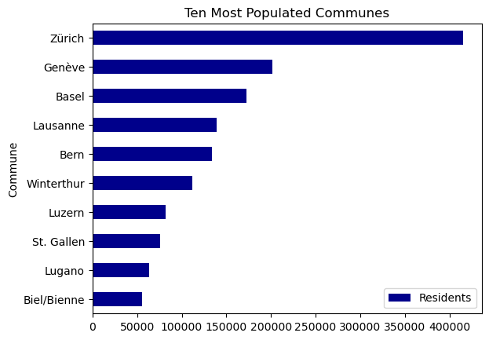

```python
print("Horizontal bar chart of the ten most polulated communes:\n ")

ten_most_populated_communes.plot.barh(x="Commune", y="Residents",
                                      title="Ten Most Populated Communes", color="#00008B").invert_yaxis()
plt.show()
```

**2) For the top 10 populated communes of the previous step, your task now is to plot a horizontal stacked bar chart that shows how their lands are divided into the 4 area types: Settlement, Agricultural, Wooded, Unproductive. Remember that these 4 area types represent the percentages and should add up to 100 for each commune. Ensure that the chart has an appropriate title, legend and labels. Your output should look like the following plot**

```
Horizontal stacked bar chart of the types of land area in the ten most populated communes:
```

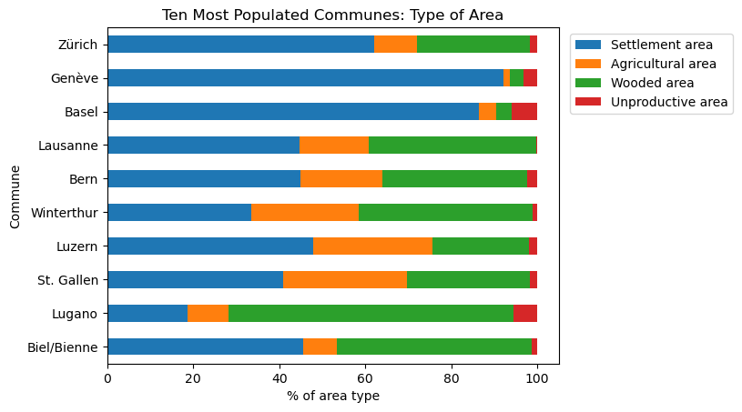

```python
print(f"Horizontal stacked bar chart of the types of land area in the ten most populated communes:\n")

ten_most_populated_communes.set_index("Commune")[["Settlement area",
                           "Agricultural area",
                           "Wooded area",
                           "Unproductive area"]].plot.barh(stacked=True).invert_yaxis()
plt.ylabel("Commune")
plt.xlabel("% of area type")
plt.title("Ten Most Populated Communes: Type of Area")
plt.legend(loc="upper right", bbox_to_anchor=(1.4, 1))
plt.show()
```

**3) We are interested in the number of communes and their proportions of young residents (0-19yrs). Your task is to obtain a histogram that shows the number of communes for which this proportion falls into the following intervals:**

**- 5%-10%**  
**- 10%-15%**  
**- 15%-20%**  
**- 20%-25%**  
**- 25%-30%**  
**- 30%-35%**

```python
print(f"Count of communes grouped by residents aged between 0 and 29 years old.\
 The percentage of young residents fall \nwithin six intervals:\n")

df["0-19 years"].value_counts(bins=[5, 10, 15, 20, 25, 30, 35], sort=False)
```

```
Count of communes grouped by residents aged between 0 and 29 years old. The percentage of young residents fall
within six intervals:
```

```
(4.999, 10.0]      15
(10.0, 15.0]       98
(15.0, 20.0]      796
(20.0, 25.0]     1109
(25.0, 30.0]      167
(30.0, 35.0]        2
Name: 0-19 years, dtype: int64
```

```
Histogram of aggregated data on communes and percentage of young residents:
```

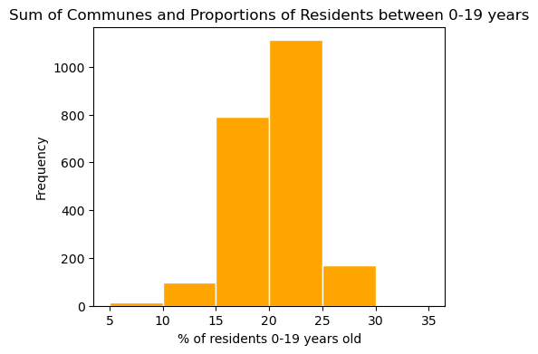

```python
print(f"Histogram of aggregated data on communes and percentage of young residents:\n")

df["0-19 years"].plot.hist(bins=[5, 10, 15, 20, 25, 30, 35], figsize=(5, 4), edgecolor="white", color="orange")

plt.xlabel("% of residents 0-19 years old")
plt.title("Sum of Communes and Proportions of Residents between 0-19 years")
plt.show()
```

**4) Your task is to investigate the distributions of the age group 0-19 years, which is a numerical variable, across four language regions, which is a categorical variable**

```
Violin plot of languages spoken amongst youth between the ages of 0-19 years:
```

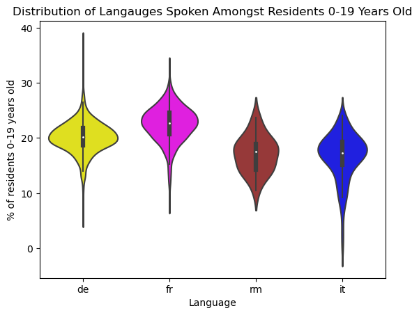

```python
print(f"Violin plot of languages spoken amongst youth between the ages of 0-19 years:\n")
palette_one = ["yellow", "magenta", "brown", "blue"]

sns.violinplot(data = df, x = "Language", y = "0-19 years", palette = palette_one)

plt.ylabel("% of residents 0-19 years old")
plt.title("Distribution of Langauges Spoken Amongst Residents 0-19 Years Old")
plt.show()
```

**5) Your task is to do the previous task for the three age groups 0-19 years, 20-64 years, and 65 years or over. In order to make the comparison easy, you should make a plot with one subplot per age group (plot with 1 row and 3 columns). Ensure that the subplots have appropriate titles, legends, and labels. Also, ensure that they have proper sizes and there is enough space between them**

**- The y-axis of the subplot should show the percentages of the populations for age groups, ranging from 0 to 80%**

**- Add the observations into your subplot to see how they form the distributions. For instance, if you chose the box plot, you can draw a strip plot on the same axis as a complement to the box plot**

```
Violin plot of languages spoken amongst all Swiss residents across three age intervals:
```

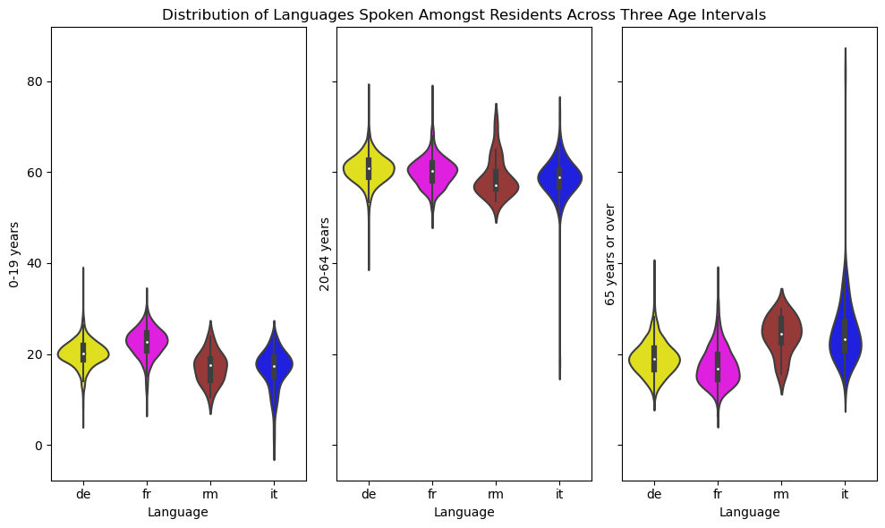

```python
print(f"Violin plot of languages spoken amongst all Swiss residents across three age intervals:\n")

fig, ax = plt.subplots(nrows = 1, ncols = 3, figsize=(10, 6), sharey=True)

sns.violinplot(data = df, x = "Language", y = "0-19 years", ax=ax[0], palette = palette_one)

sns.violinplot(data = df, x = "Language", y = "20-64 years", ax=ax[1], palette = palette_one)

sns.violinplot(data = df, x = "Language", y = "65 years or over", ax=ax[2], palette = palette_one)

ax[1].set_title("Distribution of Languages Spoken Amongst Residents Across Three Age Intervals")

fig.tight_layout()
plt.show()
```

```
Box plot and strip plot of languages spoken amongst all Swiss residents across three age intervals:
```

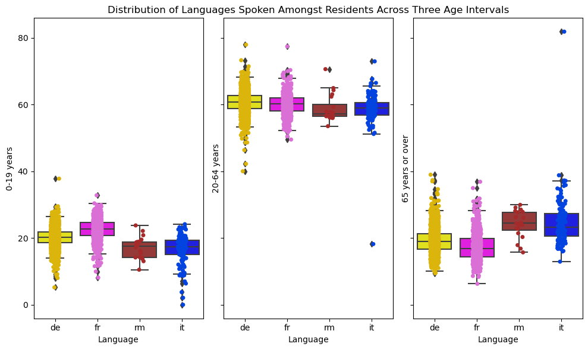

```python
print(f"Box plot and strip plot of languages spoken amongst all Swiss\
 residents across three age intervals:\n")

palette_two = ["#DBB40C", "#DA70D6", "#A52A2A", "#0343DF"]

fig, ax = plt.subplots(nrows = 1, ncols = 3, figsize=(10, 6), sharey=True)

sns.boxplot(data = df, x = "Language", y = "0-19 years", ax=ax[0],
            palette = palette_one)

sns.boxplot(data = df, x = "Language", y = "20-64 years", ax=ax[1],
            palette = palette_one)

sns.boxplot(data = df, x = "Language", y = "65 years or over", ax=ax[2],
            palette = palette_one)

sns.stripplot(data = df, x = "Language", y = "0-19 years", ax=ax[0],
              palette = palette_two)

sns.stripplot(data = df, x = "Language", y = "20-64 years", ax=ax[1],
              palette = palette_two)

sns.stripplot(data = df, x = "Language", y = "65 years or over", ax=ax[2],
              palette = palette_two)

ax[1].set_title("Distribution of Languages Spoken Amongst Residents Across Three Age Intervals")

fig.tight_layout()
plt.show()
```

**6) Your task is to use the pairplot from Seaborn and produce 3 plots to visually investigate the relation between the Agricultural area of communes and their Settlement area, Wooded area and the Unproductive area:**

**- Are the relations linear?**

**- Use the Elevation as the color-code variable in the plot and show that communes that are located in high altitudes have very low Settlement and Agricultural areas, but have a lot of Unproductive areas**

```
Pair plot that shows the variability of area type across Switzerland's geographic regions:
```

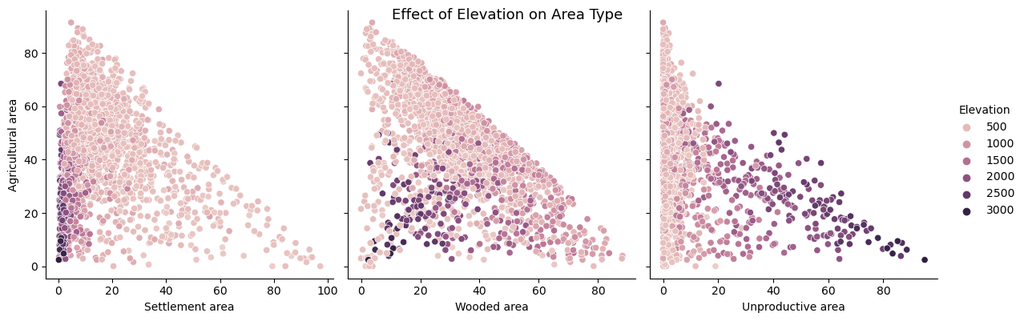

```python
print(f"Pair plot that shows the variability of area type across Switzerland's geographic regions:\n")

pairplot = sns.pairplot(df,
             x_vars = ["Settlement area", "Wooded area", "Unproductive area"],
             y_vars = "Agricultural area",
             height = 4,
             hue = "Elevation")

pairplot.fig.suptitle("Effect of Elevation on Area Type", fontsize = (13))
plt.show()
```

**7) Your task is to draw a map of Switzerland using the East and North coordinates of communes. Ensure that the plot has an appropriate title, legend and labels:**

**- Use the Elevation as the color-code variable in the plot so that the you can see the three geographic regions, namely the Swiss Alps, the Central Plateau and the Jura. Your output should look like the following plot**

**- Re-do the same plot but this time with the Language as the color-code variable**

```
Map of Switzerland's three geographic regions. The colour code of the map represents elevation variability amongst all Swiss communes:
```

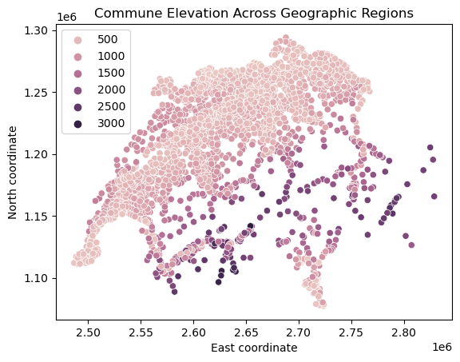

```python
print(f"Map of Switzerland's three geographic regions. The colour code of the map\
 represents elevation variability amongst all Swiss communes:\n")

sns.scatterplot(data = df, x = "East coordinate", y = "North coordinate", hue = "Elevation")

plt.title("Commune Elevation Across Geographic Regions")
plt.legend(loc = "upper left")
plt.figure(figsize = (10, 6))
plt.show()
```

```
Map of the main language spoken in each Swiss region. The colour code of the map represents the main language
spoken in each Swiss commune:
```

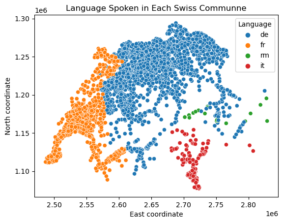

```python
print(f"Map of the main language spoken in each Swiss region. The colour\
 code of the map represents the main language \nspoken in each Swiss commune:\n")

sns.scatterplot(data = df, x = "East coordinate", y = "North coordinate", hue = "Language")

plt.title("Language Spoken in Each Swiss Communne")
plt.figure(figsize = (10, 6))
plt.show()
```

**8) Your task is to obtain the two plots from the previous task as subplots (with 1 row and 2 columns). Ensure that the plots have appropriate titles, legends and labels. Also, ensure that they have proper sizes and there is enough space between them.**

```
Subplots of two maps illustrating elevation variability and languages spoken across all three Swiss geographic regions:
```

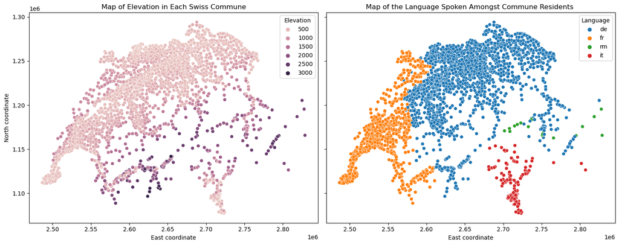

```python
print(f"Subplots of two maps illustrating elevation variability and languages\
 spoken across all three Swiss geographic regions:\n")

fig, ax = plt.subplots(nrows = 1, ncols = 2, figsize = (15, 6), sharey=True)

sns.scatterplot(data = df, x = "East coordinate", y = "North coordinate",
                hue = "Elevation", ax=ax[0])

sns.scatterplot(data = df, x = "East coordinate", y = "North coordinate",
                hue = "Language", ax=ax[1])

ax[0].set_title("Map of Elevation in Each Swiss Commune")
ax[1].set_title("Map of the Language Spoken Amongst Commune Residents ")

fig.tight_layout()
plt.show()
```

## D. Probabilities

**Compute the probability that a randomly selected commune with elevation over 2000 is from the canton of Valais.**

```python
all_communes_in_valais_with_elevation_over_two_thousand = df[
    (df["Elevation"] > 2000)].groupby("Canton").get_group("VS").count()["Commune"]

all_communes_with_elevation_over_two_thousand = df[
    (df["Elevation"] > 2000)].count()["Commune"]

print(f"The probability of randomly selecting a commune in the canton of Valais with an\
 elevation over \ntwo thousand is\
 {all_communes_in_valais_with_elevation_over_two_thousand / all_communes_with_elevation_over_two_thousand}.")
```

```
The probability of randomly selecting a commune in the canton of Valais with an elevation over
two thousand is 0.5104166666666666.
```

## E. Matrices

**Define a data frame matrix whose rows correspond to communes and the columns to the cantons. Fill in the matrix with 0/1 values where entry *(i,j)* is a 1 if the commune in row *i* is in the canton in column *j* and a 0 otherwise.**

```python
print(f"Dataframe matrix with rows that correspond to commune and columns to canton;\
 1 demonstrates that the commune is in the canton while 0 indicates that the commune\
 is not in the canton:\n")

df_matrix = pd.crosstab(df["Commune"], df["Canton"])

df_matrix
```

```
Dataframe matrix with rows that correspond to commune and columns to canton; 1 demonstrates that the commune is in the canton while 0 indicates that the commune is not in the canton:
```

| Canton Commune | AG | AI | AR | BE | BL | BS | FR | GE | GL | GR | ... | SH | SO | SZ | TG | TI | UR | VD | VS | ZG | ZH |
| --- | --- | --- | --- | --- | --- | --- | --- | --- | --- | --- | --- | --- | --- | --- | --- | --- | --- | --- | --- | --- | --- |
| Aadorf | 0 | 0 | 0 | 0 | 0 | 0 | 0 | 0 | 0 | 0 | ... | 0 | 0 | 0 | 1 | 0 | 0 | 0 | 0 | 0 | 0 |
| Aarau | 1 | 0 | 0 | 0 | 0 | 0 | 0 | 0 | 0 | 0 | ... | 0 | 0 | 0 | 0 | 0 | 0 | 0 | 0 | 0 | 0 |
| Aarberg | 0 | 0 | 0 | 1 | 0 | 0 | 0 | 0 | 0 | 0 | ... | 0 | 0 | 0 | 0 | 0 | 0 | 0 | 0 | 0 | 0 |
| Aarburg | 1 | 0 | 0 | 0 | 0 | 0 | 0 | 0 | 0 | 0 | ... | 0 | 0 | 0 | 0 | 0 | 0 | 0 | 0 | 0 | 0 |
| Aarwangen | 0 | 0 | 0 | 1 | 0 | 0 | 0 | 0 | 0 | 0 | ... | 0 | 0 | 0 | 0 | 0 | 0 | 0 | 0 | 0 | 0 |
| ... | ... | ... | ... | ... | ... | ... | ... | ... | ... | ... | ... | ... | ... | ... | ... | ... | ... | ... | ... | ... | ... |
| Zwieselberg | 0 | 0 | 0 | 1 | 0 | 0 | 0 | 0 | 0 | 0 | ... | 0 | 0 | 0 | 0 | 0 | 0 | 0 | 0 | 0 | 0 |
| Zwingen | 0 | 0 | 0 | 0 | 1 | 0 | 0 | 0 | 0 | 0 | ... | 0 | 0 | 0 | 0 | 0 | 0 | 0 | 0 | 0 | 0 |
| Zwischbergen | 0 | 0 | 0 | 0 | 0 | 0 | 0 | 0 | 0 | 0 | ... | 0 | 0 | 0 | 0 | 0 | 0 | 0 | 1 | 0 | 0 |
| Zäziwil | 0 | 0 | 0 | 1 | 0 | 0 | 0 | 0 | 0 | 0 | ... | 0 | 0 | 0 | 0 | 0 | 0 | 0 | 0 | 0 | 0 |
| Zürich | 0 | 0 | 0 | 0 | 0 | 0 | 0 | 0 | 0 | 0 | ... | 0 | 0 | 0 | 0 | 0 | 0 | 0 | 0 | 0 | 1 |

2191 rows × 26 columns